# Untitled

2024-04-05

```r
library(readxl)
library(tidyverse)
library(openxlsx)
library(zoo)
library(kableExtra) # Para las tablas
```

# Ideas

Superávit Primario: Después de 13 años de déficits primarios, en el 2022 se logró un superávit primario de ¢927.392 millones (equivalente al 2,1% del PIB 2022). Esto marca un cambio importante, ya que anteriormente se habían registrado déficits primarios. Además, se cumplió con la meta pactada con el Fondo Monetario Internacional (FMI). Déficit Financiero: A pesar de registrar un pago de intereses por 4,6% del PIB, el déficit financiero en el 2022 se redujo a ¢1.116.751 millones (equivalente al 2,5% del PIB 2022), cifra menor en comparación con el año anterior. Es importante destacar que el pago de intereses de la deuda alcanzó su nivel más alto en los últimos 17 años. Deuda Pública: La deuda a diciembre del 2022 alcanzó ¢28.223.523 millones, por debajo de la meta evaluativa acordada con el FMI. La razón Deuda/PIB también disminuyó a 63,8% del PIB 2022. Ingresos Totales: Los ingresos totales a diciembre fueron de ¢7.341.175 millones (equivalente al 16,6% del PIB 2022), mayor en comparación con el mismo período del 2021. Gasto Total: El gasto total sin intereses a diciembre fue de ¢6.413.783 millones (equivalente al 14,5% del PIB 2022), presentando un decrecimiento en comparación con el año anterior. En el 2023, el déficit fiscal aumentó nuevamente a 3,3% del PIB, atribuido a un mayor pago de intereses sobre la deuda. Sin embargo, en junio del 2023, se registró un déficit financiero de 0,9% del PIB, el mejor resultado de los últimos 13 años.

Como se ha analizado en el presente informe Costa Rica en los años 2022 y 2023 esta mostrando una mejora a en la economía en el caso del déficit fiscal no es la excepción. En siguiente gráfico esta representado el comportamiento del ingreso y gastos públicos.

```r
library(reshape2)
```

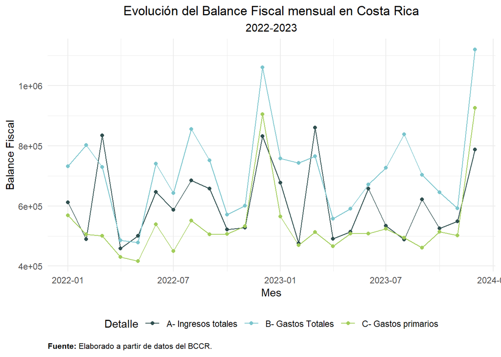

```r
Deficit_Fiscal <- read_excel("Deficit Fiscal.xlsx")

Balance_Fiscal_L <- melt(
    Deficit_Fiscal,
    id.vars = "Detalle",
    variable.name = "Mes",
    value.name = "Balance"
  ) %>%
  mutate()


Balance_Fiscal_L$Mes <- Balance_Fiscal_L$Mes %>%
  as.character() %>%
  as.numeric()
Balance_Fiscal_L <- Balance_Fiscal_L %>%
  mutate(
    MesD =
      as.Date(
        Balance_Fiscal_L$Mes,
        origin = "1899-12-30"
        )
    )

Balance_Fiscal_L %>%
  filter(
    Detalle ==
        "A- Ingresos totales" |
    Detalle ==
       "B- Gastos Totales" |
    Detalle ==
      "C- Gastos primarios"
    ) %>%
  ggplot(
    aes(
      y =
        Balance,
      x =
        MesD,
      color =
        Detalle
      )
  )+
  geom_line(
    ) +
  geom_point(
    ) +
  labs(
    x =
      "Mes",
    y =
      "Balance Fiscal",
    title =
      "Evolución del Balance Fiscal mensual en Costa Rica",
    subtitle =
      "2022-2023") +
  theme_minimal() +
    theme(
      legend.position =
        "bottom",
      plot.title =
        element_text(
          hjust =
            0.5
        ),
      plot.subtitle =
        element_text(
          hjust =
            0.5
        ),
      plot.caption =
        element_text(
          hjust =
            0,
          color =
            "black",
          size =
            8
          )
      ) +
  labs(
    caption =
      expression(
        bold(
          "Fuente: "
          ) * "Elaborado a partir de datos del BCCR."
        )
    ) + scale_color_manual(
    values =
      c(
        "#2F4F4F",
        "cadetblue3",
        "#A2CD5A"
      )
    )
```

```r
PIB <- read_excel("PIB Trimestral.xlsx")
PIB$Trimestre <- as.yearqtr(PIB$Trimestre)

rep(PIB$`Producto Interno Bruto a precios de mercado`,each= 3)
```

```
##  [1]  9559153  9559153  9559153  9653062  9653062  9653062  9804771  9804771
##  [9]  9804771  9967346  9967346  9967346  9941039  9941039  9941039 10186509
## [17] 10186509 10186509 10336319 10336319 10336319 10493067 10493067 10493067
```

```r
rep(1:8,3)
```

```
##  [1] 1 2 3 4 5 6 7 8 1 2 3 4 5 6 7 8 1 2 3 4 5 6 7 8
```

```r
# Deficit_Fiscal %>%
#   mutate(`A Ingreso mensual` =
#            c(`A- Ingresos totales`[1],
#              diff(`A- Ingresos totales`[1:12]),
#              `A- Ingresos totales`[13],
#              diff(`A- Ingresos totales`[13:24]))) %>%
#   mutate(`B Gasto mensual` =
#            c(`B- Gastos totales`[1],
#              diff(`B- Gastos totales`[1:12]),
#              `B- Gastos totales`[13],
#              diff(`B- Gastos totales`[13:24]))) %>%
#   # ggplot(aes(x=Mes,y = `A Ingreso mensual`)) +
#   # geom_bar(stat="identity")+
#   # geom_line(aes(x=Mes,y = `B Gasto mensual`))
#   mutate(`C Balance Fiscal`= `A Ingreso mensual` -
#            `B Gasto mensual`) %>%
#   mutate(PIB = rep(PIB$`Producto Interno Bruto a precios de mercado`,each= 3)) %>%
#   mutate(`Balance Porcentual` = `C Balance Fiscal`/PIB*100) %>%
#   ggplot(aes(x=Mes,y=`Balance Porcentual`,fill=`Balance Porcentual`))+
#     geom_bar(stat = "identity")+
#   labs(title =
#          "Balance Fiscal",
#        subtitle =
#          "Como porcentaje del PIB"
#        )+
#   scale_fill_gradient(low="#2F4F4F", high="cadetblue3")+
#   theme_minimal() +
#   theme(legend.position =
#           "none")
#
#
#
# Deficit_Fiscal$`A- Ingresos totales`
```